# 베이즈데이터분석

김동현

2022-11-27

```r
library(ggplot2)
library(GGally)
library(dplyr)
library(Hmisc)
library(rstan)
library(ggmcmc)
library(ggmosaic)
library(psych)
library(formattable)
library(reshape2)
library(coda)
```

# 문제1

#### (a) 밀도함수의 개형을 R을 이용해 그리시오.

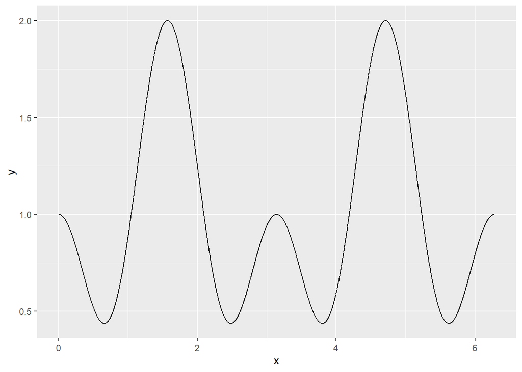

```r
n = 10000
u = runif(n, min=0, max=2*pi)
y = sin(u)^2 + cos(2*u)^2

df = data.frame(x=u, y=y)

df %>% ggplot(aes(x=x, y=y)) + geom_line()
```

#### (b) f(x) 의 최대값을 구하시오.

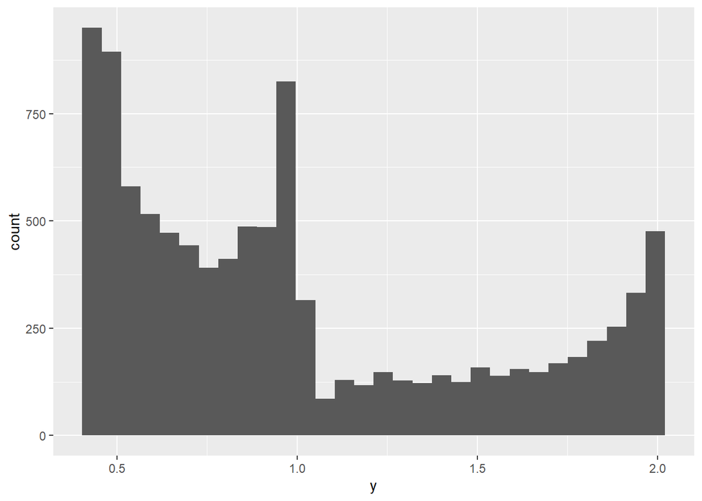

```r
df %>% ggplot(aes(x=y)) + geom_histogram()
```

```r
summary(y)
```

```
##    Min. 1st Qu.  Median    Mean 3rd Qu.    Max.
##  0.4375  0.5719  0.8731  1.0013  1.3734  2.0000
```

f(x)의 최대값은 2

#### (c) U[0, 2π] 를 제안밀도함수로 하여 합격-불합격 방법 알고리듬을 서술하시오.

밀도함수의 최대값이 2이므로 M 값을 2로 하여 합격-불합격 방법을 적용한다.  
x가 [0, 2π] 일 때, 주어진 x에 대해 (sin(x)^2 + cos(2*x)^2)/M 값이 u 보다 크거나 같으면 x를 반환하는 rtri1() 함수를 만들고, 주어진 n만큼 반복하여 실행하여 표본을 추출한다.

```r
rtri1 = function() {
  M = 2
  accept = FALSE
  while(accept == FALSE) {
    x = runif(1, min=0, max=2*pi)
    u = runif(1, min=0, max=1)
    accept_prob = (sin(x)^2 + cos(2*x)^2)/M
    if ( u <= accept_prob ) {
      accept = TRUE
    }
  }
  return(x)
}

rtri = function(n) {
  x = numeric(n)
  for(i in 1:n) x[i]=rtri1()

  return(x)
}
```

#### (d) 위에서 서술한 알고리듬으로 5000개의 랜덤표본을 R을 이용해 f(x)에서 추출하고, 히스토그램을 그리시오. 표본평균과 표본 표준편차를 구하시오.

```r
n = 5000
x = rtri(n)
y = sin(x)^2 + cos(2*x)^2
```

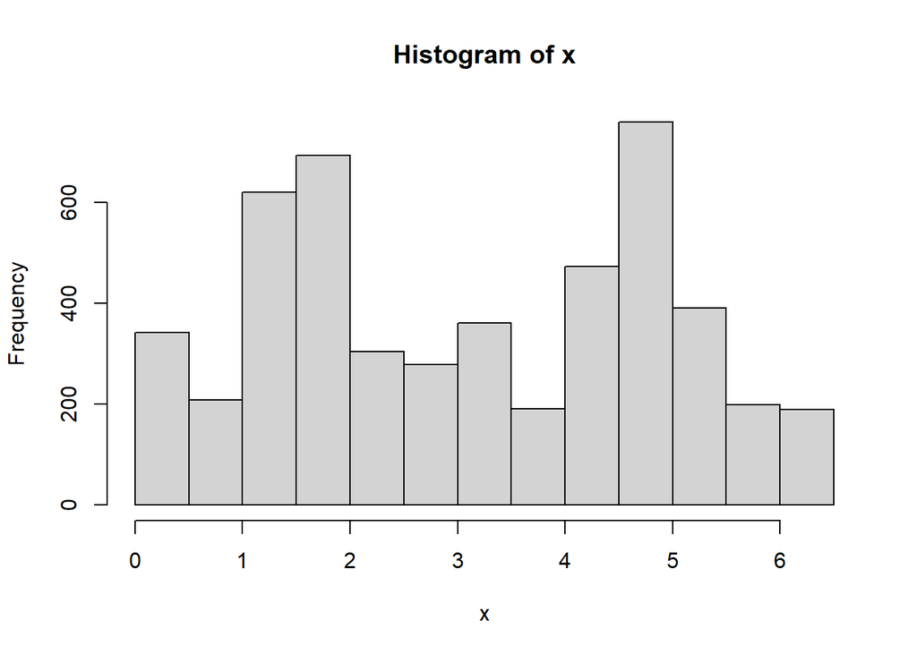

```r
hist(x)
```

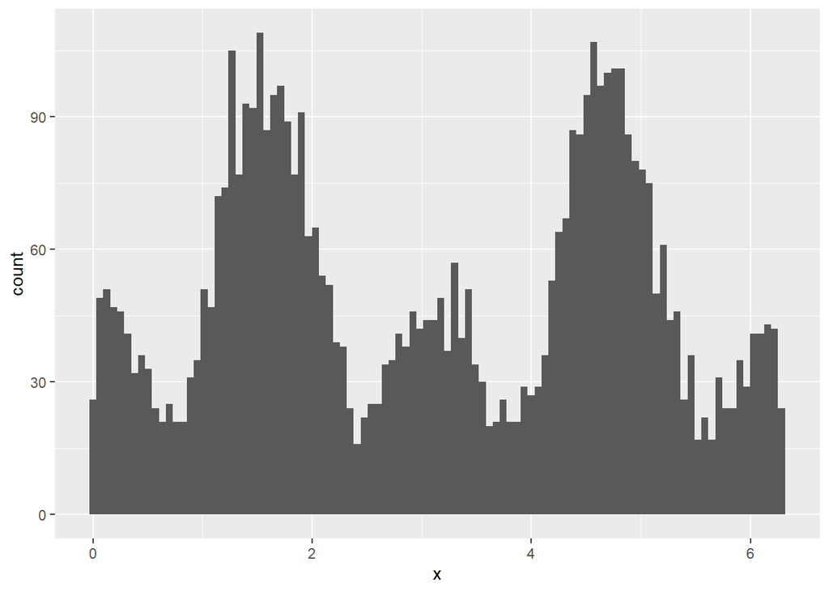

```r
data.frame(x=x) %>% ggplot(aes(x=x)) + geom_histogram(bins=100)
```

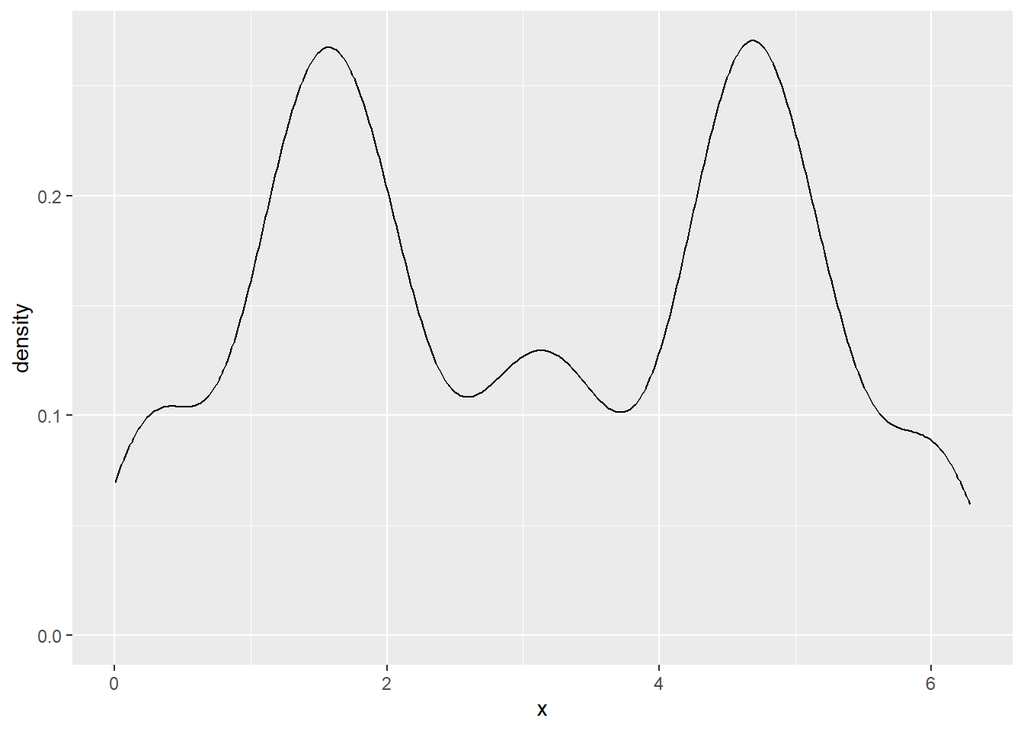

```r
data.frame(x=x) %>% ggplot(aes(x=x)) + geom_density()
```

```r
summary(x)
```

```
##     Min.  1st Qu.   Median     Mean  3rd Qu.     Max.
## 0.001095 1.550487 3.079365 3.101987 4.676971 6.281991
```

```r
sd(x)
```

```
## [1] 1.753401
```

# 문제2

#### θ ~ N(0,1) I(θ≥3) 에서 분할추출법을 이용하여 표본을 추출하고자 한다. 다음에 답하시오

#### a) 책의 예 9-4를 참고하여 분할추출 알고리듬을 서술하시오.

9-4 예제와 비교해보면 A=3이고, 이는 합격확률이 매우 낮아지는 조건이라 할 수 있다.  
따라서 합격-불합격 방법으로 표본을 추출하기 어렵다. 다시 말하자면 정규분포의 꼬리에서 표본을 추출하는 것이 쉽지 않다.  
이런 경우에는 π(x)를 분할추출법을 이용한다. 정규분포를 적분하여 π(x,z)로 변경하고, 여기서 깁스추출법을 사용한다.

#### b) 5000개의 표본을 추출하고 히스토그램을 그리시오. 표본평균과 표본 표준편차를 구하시오.

```r
m = 5000
mu = 0
sig = 1
A = 3

po.theta = NULL
po.z = NULL

theta = max(A+0.5*sig, mu)

for(t in 1:m) {
  z = runif(1, 0, exp(-0.5*(theta-mu)^2/sig^2))
  temp = sqrt(-2*sig^2*log(z))
  theta = runif(1, max(A,mu-temp), mu+temp)
  po.z = c(po.z, z)
  po.theta = c(po.theta, theta)
}

post = data.frame(theta=po.theta, z=po.z)
```

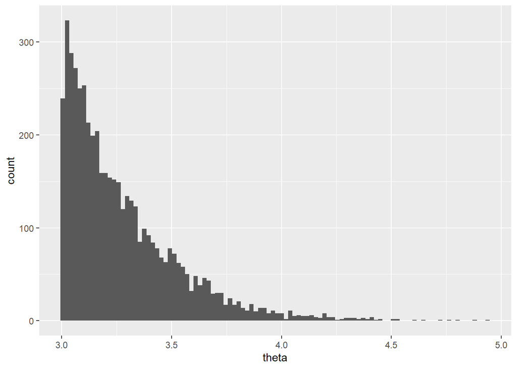

```r
post %>% ggplot(aes(x=theta)) + geom_histogram(bins=100)
```

```r
post %>% mcmc %>% summary
```

```
##
## Iterations = 1:5000
## Thinning interval = 1
## Number of chains = 1
## Sample size per chain = 5000
##
## 1. Empirical mean and standard deviation for each variable,
##    plus standard error of the mean:
##
##           Mean       SD  Naive SE Time-series SE
## theta 3.277160 0.258906 3.661e-03      6.019e-03
## z     0.002933 0.002484 3.512e-05      5.651e-05
##
## 2. Quantiles for each variable:
##
##            2.5%       25%      50%      75%    97.5%
## theta 3.008e+00 3.0833012 3.203908 3.396316 3.953451
## z     4.775e-05 0.0008523 0.002286 0.004463 0.008775
```

# 문제3

#### (a) 스탠을 이용하여 번인 5000개를 포함하여 총 15,000개의 사후표본을 추출하시오.

```r
options(mc.cores = parallel::detectCores())
rstan_options(auto_write = TRUE)
```

#### R 코드

```r
x = matrix(c(57.8, 27.2,
             58.6, 26.8,
             60.8, 29.9,
             57.6, 28.0,
             58.1, 27.8,
             60.4, 26.7,
             56.7, 30.8,
             60.0, 27.1,
             56.7, 26.5,
             54.3, 27.9), nrow=10, ncol=2, byrow=T);

n = nrow(x)
data = list(x=x, n=n)

parameters = c("rho", "mu", "sigma")

samples = stan(model_code=model, data=data, pars=parameters, iter=20000, chains=1, thin=10, warmup=5000, seed=1234567)
```

#### (b) 모수들의 사후표본의 밀도함수 그림, 시계열 그림, 자기상관계수 그림을 그리고 마르코프 체인이 수렴했는지 판단하시오. 수렴하지 않았다고 판단하면 수렴했다고 판단할 때까지 사후표본의 크기를 늘리시오.

#### 결과 확인

```r
print(samples)
```

```
## Inference for Stan model: anon_model.
## 1 chains, each with iter=20000; warmup=5000; thin=10;
## post-warmup draws per chain=1500, total post-warmup draws=1500.
##
##            mean se_mean   sd   2.5%    25%    50%    75%  97.5% n_eff Rhat
## rho       -0.03    0.01 0.26  -0.50  -0.22  -0.04   0.15   0.45  1464    1
## mu[1]     58.10    0.02 0.63  56.82  57.70  58.11  58.51  59.36  1397    1
## mu[2]     27.86    0.01 0.45  26.95  27.55  27.87  28.17  28.71  1455    1
## sigma[1]   1.98    0.00 0.00   1.98   1.98   1.98   1.98   1.98     1    1
## sigma[2]   1.42    0.00 0.00   1.42   1.42   1.42   1.42   1.42     1    1
## lp__     -21.43    0.03 1.17 -24.49 -22.00 -21.10 -20.59 -20.10  1450    1
##
## Samples were drawn using NUTS(diag_e) at Sun Nov 27 23:23:09 2022.
## For each parameter, n_eff is a crude measure of effective sample size,
## and Rhat is the potential scale reduction factor on split chains (at
## convergence, Rhat=1).
```

```
## ci_level: 0.8 (80% intervals)
```

```
## outer_level: 0.95 (95% intervals)
```

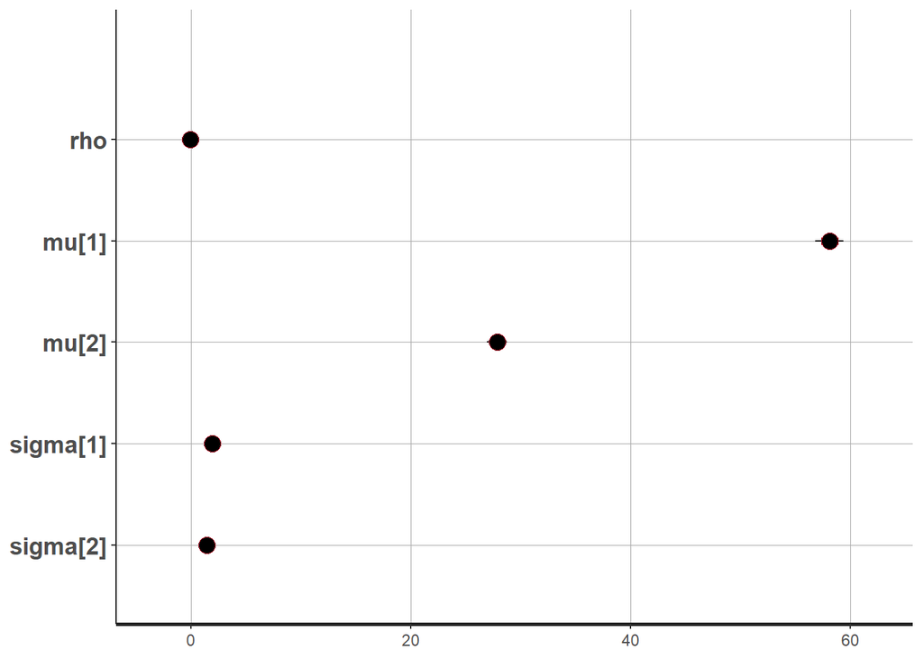

```r
plot(samples, plotfun="plot")
```

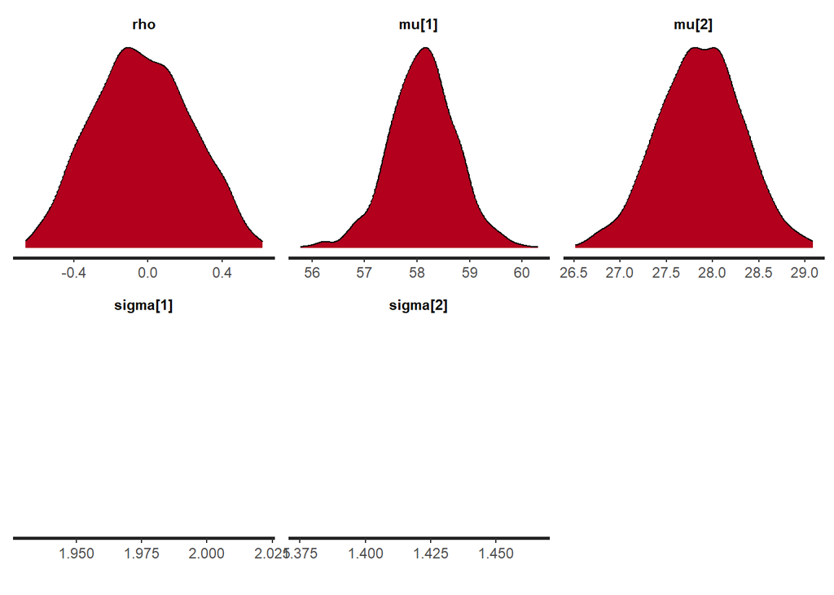

```r
plot(samples, plotfun="dens")
```

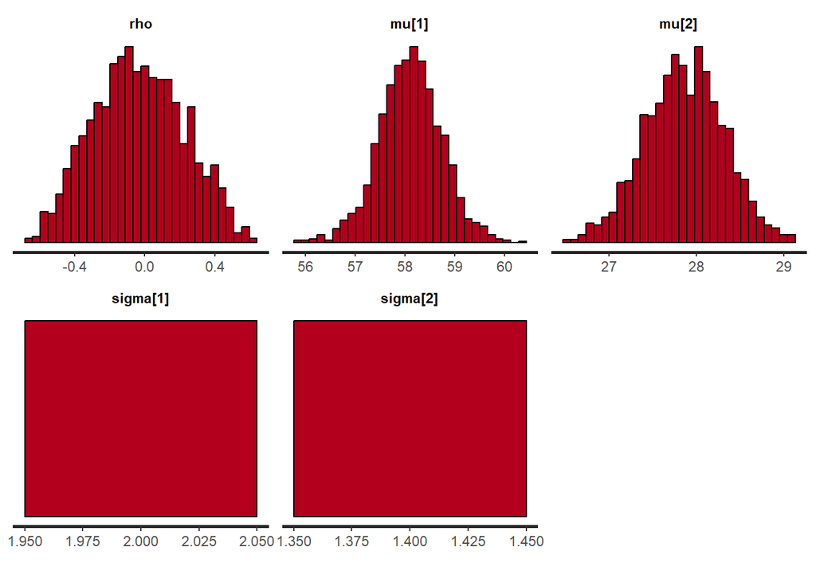

```r
plot(samples, plotfun="hist")
```

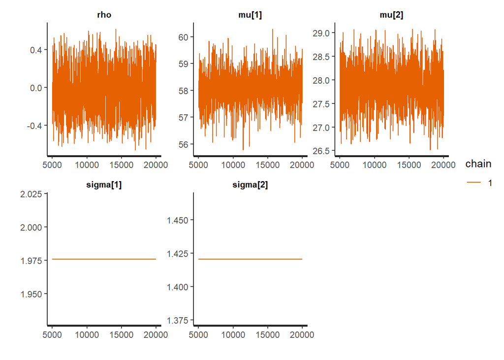

```r
plot(samples, plotfun="trace")
```

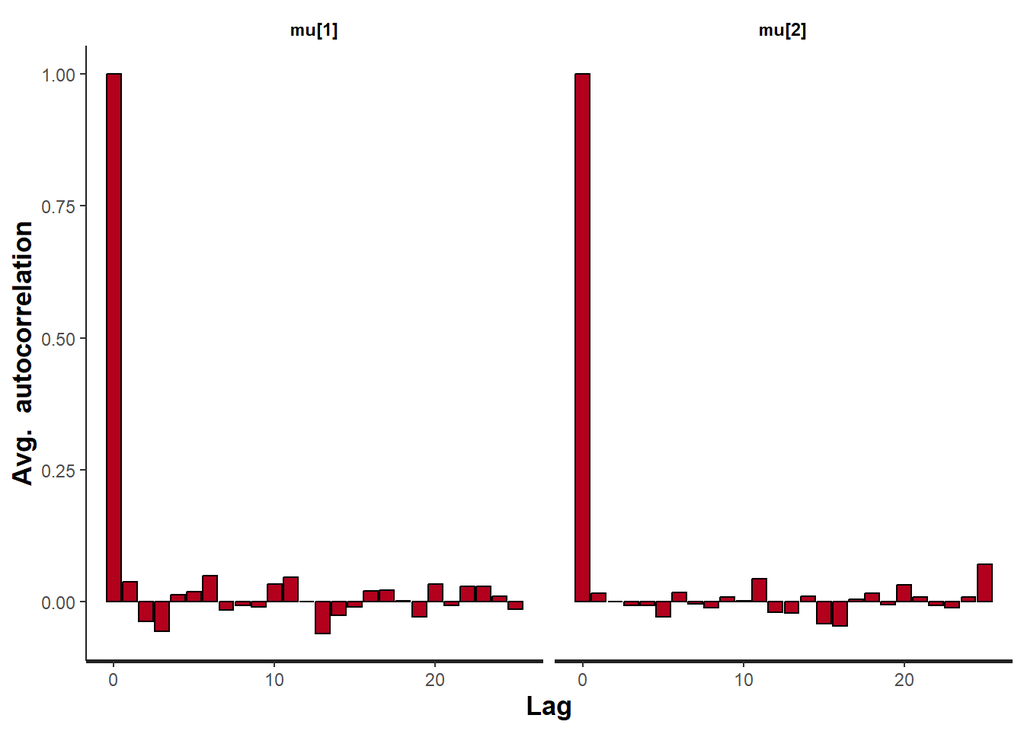

```r
plot(samples, plotfun="ac", pars="mu")
```

mu[1], mu[2]를 보면, 정규분포 형태를 유지하고 있고, 시계열 그림도 양호하며, 자기상관계수도 빠른 횟수 안에 0으로 수렴하고 있음을 알 수 있다. 따따라서 마르코프체인이 수렴했다고 판단된다.

#### (c) 모수들의 사후평균, 사후표준편차, 95% 신용구간을 구하시오.

# 문제4

#### 다음은 10명의 남성들의 2라운드 골프 기록이다.

#### 1라운드 92, 91, 85, 93, 87, 82, 100, 108, 82, 87

#### 2라운드 93, 86, 88, 83, 79, 77, 108, 110, 85, 88

#### 위의 데이터에 다음의 모형을 적합하고자 한다.

#### (모형 수식은 생략)

#### x<sub>i</sub>와 y<sub>i</sub>는 i번째 남성의 1라운드와 2라운드 기록을 나타낸다. 다음의 질문에 답하시오.

#### (a) 위 데이터의 산점도를 그리시오.

```r
round1 = c(92, 91, 85, 93, 87, 82, 100, 108, 82, 87);
round2 = c(93, 86, 88, 83, 79, 77, 108, 110, 85, 88);

data_input = data.frame(r1=round1, r2=round2)

summary(data_input)
```

```
##        r1               r2
##  Min.   : 82.00   Min.   : 77.00
##  1st Qu.: 85.50   1st Qu.: 83.50
##  Median : 89.00   Median : 87.00
##  Mean   : 90.70   Mean   : 89.70
##  3rd Qu.: 92.75   3rd Qu.: 91.75
##  Max.   :108.00   Max.   :110.00
```

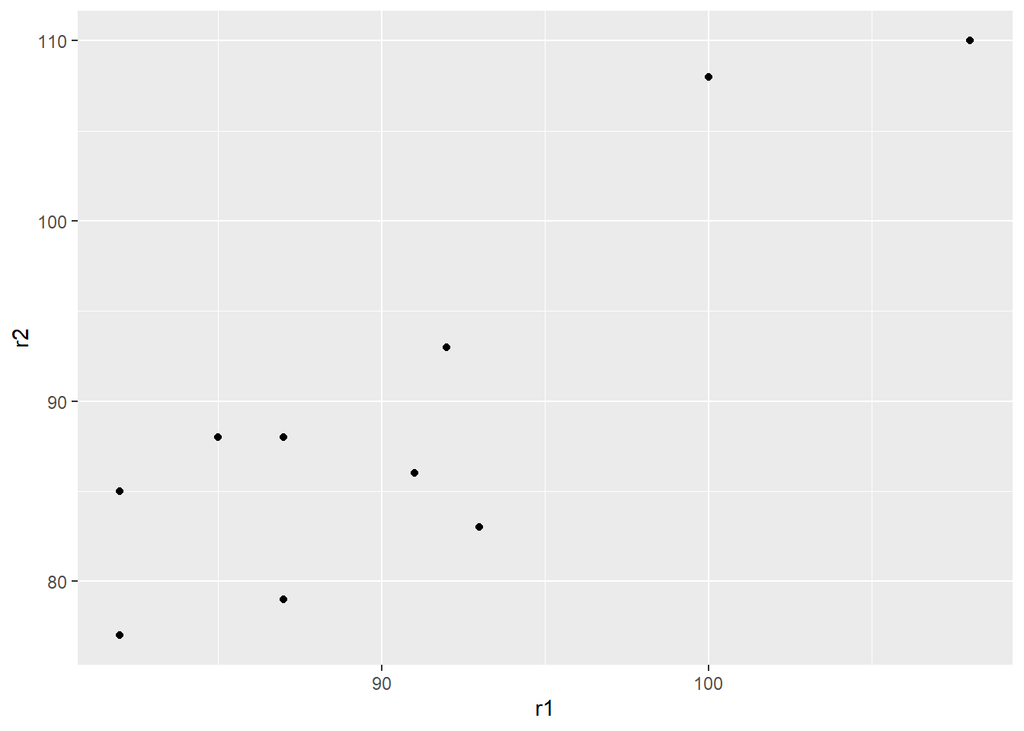

```r
ggplot(data_input, aes(x=r1, y=r2)) + geom_point();
```

#### (b) 위 모형을 적합하기 위한 스탠과 R 코드를 작성하고, 사후표본을 구하시오.

```r
model1.code ="
data {
  int<lower=0> n;
  vector[n] r1;
  vector[n] r2;
}

parameters {
  real alpha;
  real beta;
  real<lower=0> sigma;
}

model {
  for(i in 1:n) {
    r2[i] ~ normal(alpha + beta*r1[i], sigma);
  }

  target += 1/sigma^2;
}
"

data=list(n=dim(data_input)[1], r2=data_input$r2, r1=data_input$r1)
```

```r
model1 = stan(model_code=model1.code, data=data, seed=1234567, chains=2, warmup=5000, iter=20000, thin=10)
```

#### (c) 모수들의 사후표본의 밀도함수 그림, 시계열 그림, 자기상관계수 그림을 그리고 마르코프 체인이 수렴했는지 판단하시오. 수렴하지 않았다고 판단하면 수렴했다고 판단할 때까지 사후표본의 크기를 늘리시오.

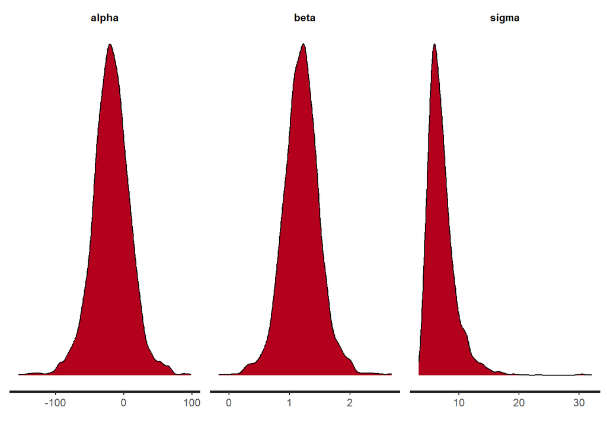

```r
plot(model1, plotfun="dens")
```

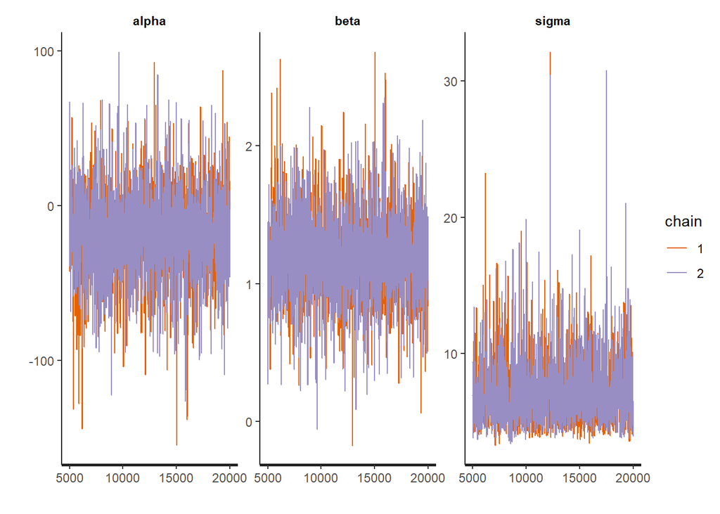

```r
plot(model1, plotfun="trace")
```

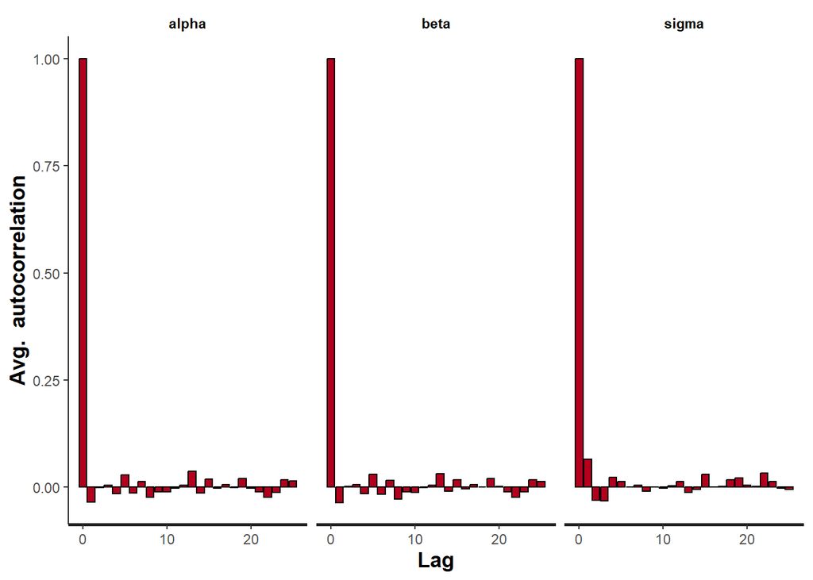

```r
plot(model1, plotfun="ac")
```

#### (d) (α,β,σ<sup>2</sup>)의 베이즈 추정량을 구하고, 기록의 예측식을 써라.

```r
print(model1)
```

```
## Inference for Stan model: anon_model.
## 2 chains, each with iter=20000; warmup=5000; thin=10;
## post-warmup draws per chain=1500, total post-warmup draws=3000.
##
##         mean se_mean    sd   2.5%    25%    50%    75%  97.5% n_eff Rhat
## alpha -18.57    0.48 27.38 -74.87 -35.07 -18.50  -1.92  35.98  3222    1
## beta    1.19    0.01  0.30   0.60   1.01   1.19   1.37   1.82  3170    1
## sigma   7.05    0.05  2.41   4.07   5.49   6.55   8.01  12.90  2655    1
## lp__  -21.63    0.03  1.51 -25.34 -22.34 -21.21 -20.54 -19.93  2761    1
##
## Samples were drawn using NUTS(diag_e) at Sun Nov 27 23:24:46 2022.
## For each parameter, n_eff is a crude measure of effective sample size,
## and Rhat is the potential scale reduction factor on split chains (at
## convergence, Rhat=1).
```

베이즈 추정량은 다음과 같다.  
α: -18.57  
β: 1.19  
σ<sup>2</sup>: 49.70

기록의 예측식은 다음과 같다.  
r2 = -18.57 + 1.19*r1 + ε, ε ~ N(0, 7.05<sup>2</sup>)

### (e) (α,β,σ<sup>2</sup>)의 95% 신용구간을 구하라.

95% 신용구간은 다음과 같다.  
α: [-74.87 ~ 35.98]  
β: [0.60 ~ 1.82] σ<sup>2</sup>: [16.56 ~ 166.41]

### (f) 1라운드 기록이 84인 남성이 있었다고 한다. 이 남성의 2라운드 기록을 예측해보시오. 이 남성의 2라운드 기록의 베이즈 추정량을 구하고, 95% 예측구간을 구하시오. 확률변수의 신용구간은 예측구간이라 한다.

기록 예측식에 따라 1라운드 기록이 84인 경우 2라운드 기록의 베이즈 추정량은  
r2 = -18.57 + 1.19*84 = 81.39 이다.

오차가 표준편차가 7.05인 정규분포에 근사한다고 보면, 95% 구간은  
[81.39 - 7.05 * 1.96 ~ 81.9 + 7.05 * 1.96]  
= [67.57 ~ 95.21] 이다.